# Analisis Regresi Multipel menggunakan data mtcars

#### Oleh: Muhammad Rasyid Ridha

## Pendahuluan

Metode yang akan digunakan untuk menganalisis data `mtcars` adalah regresi multipel linear dengan variabel `mpg` (Miles per Gallon) bertindak sebagai variabel dependen (Y) dan variabel lainnya bertindak sebagai variabel independen (X). Berikut ini deskripsi variabel dalam data `mpg`:

- `mpg` Miles/(US) gallon
- `cyl` Number of cylinders
- `disp` Displacement (cu.in.)
- `hp` Gross horsepower
- `drat` Rear axle ratio
- `wt` Weight (1000 lbs)
- `qsec` 1/4 mile time
- `vs` V/S
- `am` Transmission (0 = automatic, 1 = manual)
- `gear` Number of forward gears
- `carb` Number of carburetors

## Membaca Data

```r
mtc <- mtcars
head(mtc)
```

```
##                    mpg cyl disp  hp drat    wt  qsec vs am gear carb
## Mazda RX4         21.0   6  160 110 3.90 2.620 16.46  0  1    4    4
## Mazda RX4 Wag     21.0   6  160 110 3.90 2.875 17.02  0  1    4    4
## Datsun 710        22.8   4  108  93 3.85 2.320 18.61  1  1    4    1
## Hornet 4 Drive    21.4   6  258 110 3.08 3.215 19.44  1  0    3    1
## Hornet Sportabout 18.7   8  360 175 3.15 3.440 17.02  0  0    3    2
## Valiant           18.1   6  225 105 2.76 3.460 20.22  1  0    3    1
```

```r
str(mtc)
```

```
## 'data.frame':    32 obs. of  11 variables:
##  $ mpg : num  21 21 22.8 21.4 18.7 18.1 14.3 24.4 22.8 19.2 ...
##  $ cyl : num  6 6 4 6 8 6 8 4 4 6 ...
##  $ disp: num  160 160 108 258 360 ...
##  $ hp  : num  110 110 93 110 175 105 245 62 95 123 ...
##  $ drat: num  3.9 3.9 3.85 3.08 3.15 2.76 3.21 3.69 3.92 3.92 ...
##  $ wt  : num  2.62 2.88 2.32 3.21 3.44 ...
##  $ qsec: num  16.5 17 18.6 19.4 17 ...
##  $ vs  : num  0 0 1 1 0 1 0 1 1 1 ...
##  $ am  : num  1 1 1 0 0 0 0 0 0 0 ...
##  $ gear: num  4 4 4 3 3 3 3 4 4 4 ...
##  $ carb: num  4 4 1 1 2 1 4 2 2 4 ...
```

## Korelasi antar Variabel

```r
cor(mtc)
```

```
##             mpg        cyl       disp         hp        drat         wt
## mpg   1.0000000 -0.8521620 -0.8475514 -0.7761684  0.68117191 -0.8676594
## cyl  -0.8521620  1.0000000  0.9020329  0.8324475 -0.69993811  0.7824958
## disp -0.8475514  0.9020329  1.0000000  0.7909486 -0.71021393  0.8879799
## hp   -0.7761684  0.8324475  0.7909486  1.0000000 -0.44875912  0.6587479
## drat  0.6811719 -0.6999381 -0.7102139 -0.4487591  1.00000000 -0.7124406
## wt   -0.8676594  0.7824958  0.8879799  0.6587479 -0.71244065  1.0000000
## qsec  0.4186840 -0.5912421 -0.4336979 -0.7082234  0.09120476 -0.1747159
## vs    0.6640389 -0.8108118 -0.7104159 -0.7230967  0.44027846 -0.5549157
## am    0.5998324 -0.5226070 -0.5912270 -0.2432043  0.71271113 -0.6924953
## gear  0.4802848 -0.4926866 -0.5555692 -0.1257043  0.69961013 -0.5832870
## carb -0.5509251  0.5269883  0.3949769  0.7498125 -0.09078980  0.4276059
##             qsec         vs          am       gear        carb
## mpg   0.41868403  0.6640389  0.59983243  0.4802848 -0.55092507
## cyl  -0.59124207 -0.8108118 -0.52260705 -0.4926866  0.52698829
## disp -0.43369788 -0.7104159 -0.59122704 -0.5555692  0.39497686
## hp   -0.70822339 -0.7230967 -0.24320426 -0.1257043  0.74981247
## drat  0.09120476  0.4402785  0.71271113  0.6996101 -0.09078980
## wt   -0.17471588 -0.5549157 -0.69249526 -0.5832870  0.42760594
## qsec  1.00000000  0.7445354 -0.22986086 -0.2126822 -0.65624923
## vs    0.74453544  1.0000000  0.16834512  0.2060233 -0.56960714
## am   -0.22986086  0.1683451  1.00000000  0.7940588  0.05753435
## gear -0.21268223  0.2060233  0.79405876  1.0000000  0.27407284
## carb -0.65624923 -0.5696071  0.05753435  0.2740728  1.00000000
```

```r
sort(cor(mtc)[1,], decreasing = T)
```

```
##        mpg       drat         vs         am       gear       qsec
##  1.0000000  0.6811719  0.6640389  0.5998324  0.4802848  0.4186840
##       carb         hp       disp        cyl         wt
## -0.5509251 -0.7761684 -0.8475514 -0.8521620 -0.8676594
```

Dari matriks korelasi di atas, variabel yang paling berpengaruh terhadap secara linear `mpg` berturut - turut adalah `wt`, `cyl`, `disp`, `hp` dan `drat`. Terlihat juga bahwa terdapat beberapa variabel independen yang memiliki korelasi cukup tinggi satu sama lain yang dapat menyebabkan multikolinearitas sehingga model tidak baik untuk digunakan.

## Pemodelan Regresi

```r
fit1 <- lm(mpg ~ wt, data = mtc)
summary(fit1)
```

```
##
## Call:
## lm(formula = mpg ~ wt, data = mtc)
##
## Residuals:
##     Min      1Q  Median      3Q     Max
## -4.5432 -2.3647 -0.1252  1.4096  6.8727
##
## Coefficients:
##             Estimate Std. Error t value Pr(>|t|)
## (Intercept)  37.2851     1.8776  19.858  < 2e-16 ***
## wt           -5.3445     0.5591  -9.559 1.29e-10 ***
## ---
## Signif. codes:  0 '***' 0.001 '**' 0.01 '*' 0.05 '.' 0.1 ' ' 1
##
## Residual standard error: 3.046 on 30 degrees of freedom
## Multiple R-squared:  0.7528, Adjusted R-squared:  0.7446
## F-statistic: 91.38 on 1 and 30 DF,  p-value: 1.294e-10
```

Dengan menggunakan model sederhana dengan satu variabel independen, berdasarkan p-value di atas, variabel `wt` sudah signifikan (1.29e-10 < 0.01). Melalui beberapa percobaan, model dengan dua variabel independen seperti di bawah ini memberikan nilai p-value secara keseluruhan (F) yang paling kecil dibandingkan model dengan tiga variabel independen maupun selebihnya.

```r
fit2 <- lm(mpg ~ wt + hp, data = mtc)
summary(fit2)
```

```
##
## Call:
## lm(formula = mpg ~ wt + hp, data = mtc)
##
## Residuals:
##    Min     1Q Median     3Q    Max
## -3.941 -1.600 -0.182  1.050  5.854
##
## Coefficients:
##             Estimate Std. Error t value Pr(>|t|)
## (Intercept) 37.22727    1.59879  23.285  < 2e-16 ***
## wt          -3.87783    0.63273  -6.129 1.12e-06 ***
## hp          -0.03177    0.00903  -3.519  0.00145 **
## ---
## Signif. codes:  0 '***' 0.001 '**' 0.01 '*' 0.05 '.' 0.1 ' ' 1
##
## Residual standard error: 2.593 on 29 degrees of freedom
## Multiple R-squared:  0.8268, Adjusted R-squared:  0.8148
## F-statistic: 69.21 on 2 and 29 DF,  p-value: 9.109e-12
```

## Uji Diagnostik

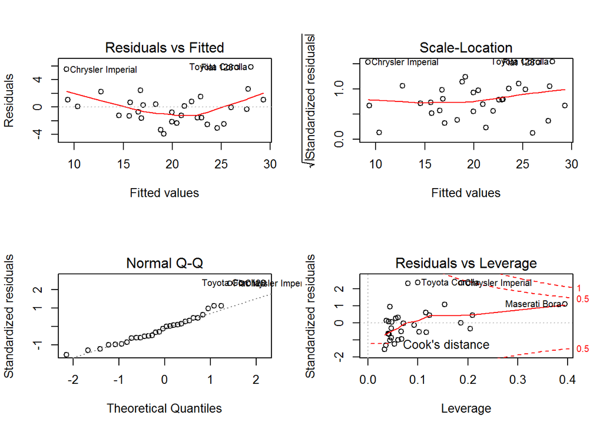

```r
layout(matrix(c(1,2,3,4),2,2))
plot(fit2)
```

## Simpulan

Model terbaik yang didapatkan berdasarkan analisis di atas adalah:

`mpg` = 37.22 - 3.87`wt` - 0.03`hp`

Meskipun terdapat beberapa variabel lain yang berkorelasi tinggi terhadap `mpg` namun tidak semua variabel yang dimasukkan ke dalam model dikarenakan sampel yang sedikit, rentannya terjadi multikolinearitas dan overfitting. Secara bersama-sama, kombinasi antara variabel `wt` dan `hp` merupakan pencerminan terbaik terhadap variabel `mpg`. Secara keseluruhan, model tersebut dapat disimpulkan bahwa:

1. Meningkatnya `wt` sebanyak 1 satuan, dengan menganggap `hp` konstan, dapat mengurangi `mpg` sebanyak rata-rata 3.87 satuan
2. Meningkatnya `hp` sebanyak 1 satuan, dengan menganggap `wt` konstan, dapat mengurangi `mpg` sebanyak rata-rata 0.03 satuan
3. Meningkatnya `wt` dan `hp` secara bersama-sama sebanyak 1 satuan dapat mengurangi `mpg` sebanyak rata-rata 3.90 satuan

### Kontak

- Email: rasyidstat@gmail.com
- Website: emrasy.id
- Resume: emrasy.id/p/cv.html
- LinkedIn: lnked.in/rasyid
- Nomor HP: +62 858 8873 8094

*“Statistician is a prognosticator, not a procrastinator”* - Me